# Regressão Simples

08-10-2014

## Antes de começar

- Esta aula é baseada no material do site [OpenIntro](http://www.openintro.org/stat/textbook.php).
- O laboratório foi traduzido pelo Professor Erikson Kaszubowski. Larga a mão de ser ruim, agradeça-o.
- Downloads
- [Banco de dados](http://www.openintro.org/stat/data/mlb11.RData)
- [Texto base](http://www.openintro.org/download.php?file=os2_lab_7A-port&referrer=/stat/labs/os2_labs-port.php)

## Motivação

[video not shown]

## Abrir banco de dados

```r
download.file("http://www.openintro.org/stat/data/mlb11.RData", destfile="mlb11.RData")
load("mlb11.RData")
```

## Exercícios - 1

Que tipo de gráfico você utilizaria para mostrar a relação entre *runs* (pontos) e alguma outra variável numérica? Crie um gráfico dessa relação utilizando a variável *at_bats* como preditora.

A relação parece ser linear? Se você soubesse o valor de *at_bats* (vez ao taco) de um time, você se sentiria confiante para utilizar um modelo linear para predizer o número de pontos (*runs*)?

## Respostas

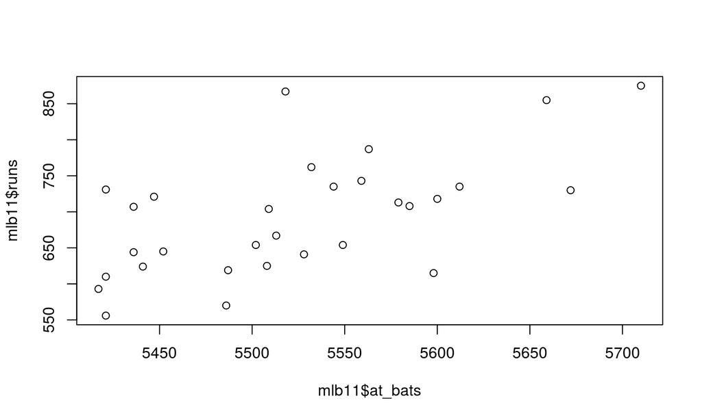

```r
plot(mlb11$at_bats, mlb11$runs)
```

R: Parece que sim…

## Exercícios - 2

Qual o coeficiente de correlação, ou seja, a força de associação destas duas variáveis?

## Resposta

```r
cor(mlb11$at_bats, mlb11$runs)
```

```
## [1] 0.6106
```

## Escolher uma melhor linha

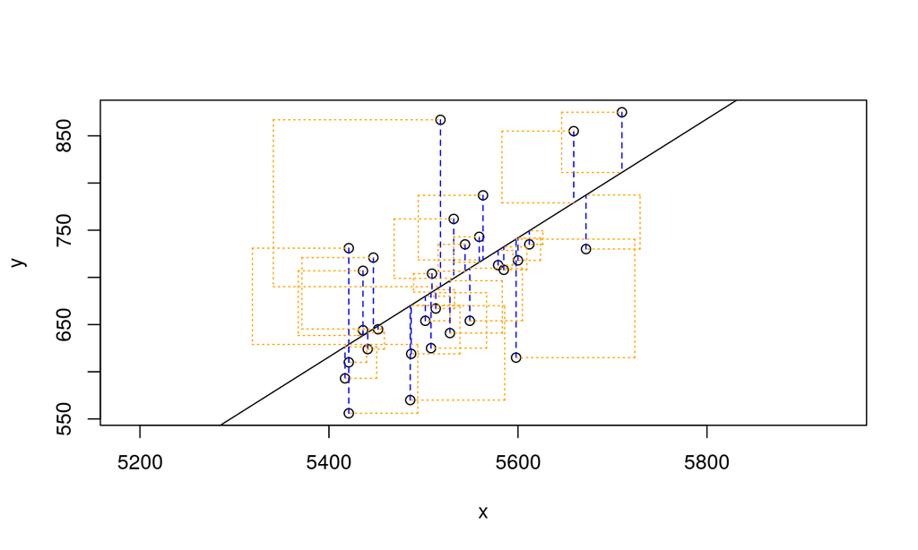

```
## Click two points to make a line.

## Call:
## lm(formula = y ~ x, data = pts)
##
## Coefficients:
## (Intercept)            x
##   -2789.243        0.631
##
## Sum of Squares:  123722
```

```r
plot_ss(mlb11$at_bats, mlb11$runs, showSquares = TRUE)
```

## Função *lm*

```r
m1 <- lm(runs ~ at_bats, data = mlb11)
```

## Resultados

```r
summary(m1)
```

```
##
## Call:
## lm(formula = runs ~ at_bats, data = mlb11)
##
## Residuals:
##    Min     1Q Median     3Q    Max
## -125.6  -47.0  -16.6   54.4  176.9
##
## Coefficients:
##              Estimate Std. Error t value Pr(>|t|)
## (Intercept) -2789.243    853.696   -3.27  0.00287 **
## at_bats         0.631      0.155    4.08  0.00034 ***
## ---
## Signif. codes:  0 '***' 0.001 '**' 0.01 '*' 0.05 '.' 0.1 ' ' 1
##
## Residual standard error: 66.5 on 28 degrees of freedom
## Multiple R-squared:  0.373,  Adjusted R-squared:  0.35
## F-statistic: 16.6 on 1 and 28 DF,  p-value: 0.000339
```

## Exercício

1. Ajuste um modelo com a variável *homeruns* para predizer *runs*. Escreva a equação da linha. O que o coeficiente angular nos diz?

## Resposta

```r
m2 <- lm(runs ~ homeruns, data = mlb11)
summary(m2)
```

```
##
## Call:
## lm(formula = runs ~ homeruns, data = mlb11)
##
## Residuals:
##    Min     1Q Median     3Q    Max
## -91.61 -33.41   3.23  24.29 104.63
##
## Coefficients:
##             Estimate Std. Error t value Pr(>|t|)
## (Intercept)  415.239     41.678    9.96  1.0e-10 ***
## homeruns       1.835      0.268    6.85  1.9e-07 ***
## ---
## Signif. codes:  0 '***' 0.001 '**' 0.01 '*' 0.05 '.' 0.1 ' ' 1
##
## Residual standard error: 51.3 on 28 degrees of freedom
## Multiple R-squared:  0.627,  Adjusted R-squared:  0.613
## F-statistic:   47 on 1 and 28 DF,  p-value: 1.9e-07
```

y = 415,2389 + 1,8345 * homeruns

## Predição e erro de predição

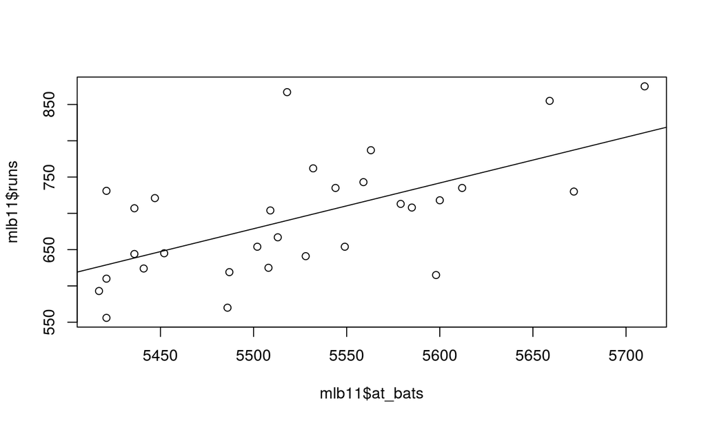

```r
plot(mlb11$runs ~ mlb11$at_bats)
abline(m1)
```

## Exercício

Se o técnico do time (dificilmente o Joel Santanta) visse a linha de regressão dos mínimos quadrados, quantos pontos (runs) ele prediria para um time com 5.578 vezes ao taco (*at_bat*)?

Esse valor superestima ou subestima o valor real? Por quanto erra?

## Resposta

Fórmula runs ~ -2789.2429 + 0.6305 * a_tbats

```r
runs  <- -2789.2429 + 0.6305 * 5578
runs
```

```
## [1] 727.7
```

## Diagnósticos do modelo - Linearidade

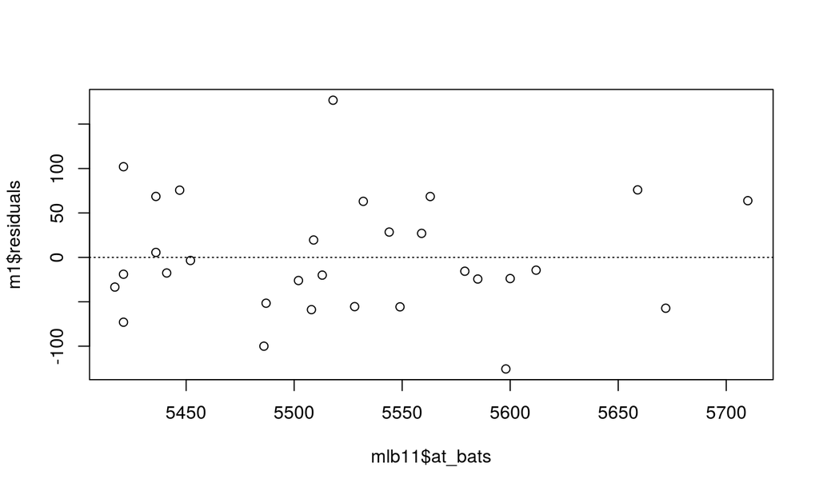

```r
plot(m1$residuals ~ mlb11$at_bats)
abline(h = 0, lty = 3)
```

Exercicio: Há algum padrão no gráfico?

## Diagnósticos do modelo - Resíduos distribuídos normalmente

- Parte do pressuposto: Constructo = Mensuração + Erro
- A condição de distribuição normal está atendida?

## Resíduos distribuídos normalmente

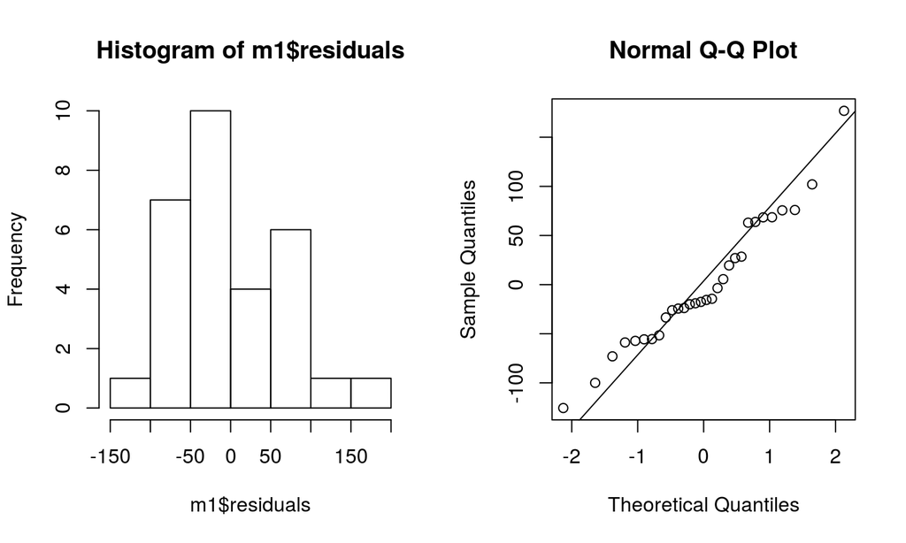

```r
par(mfrow = c(1,2))
hist(m1$residuals)
qqnorm(m1$residuals)
qqline(m1$residuals)
```

## Diagnósticos do modelo - Variância

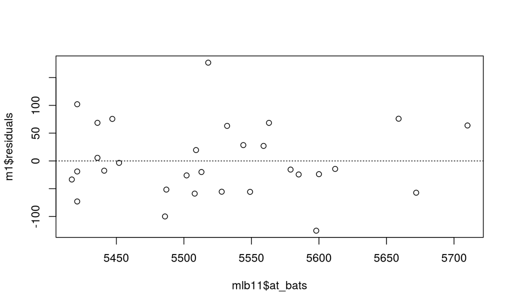

```r
plot(m1$residuals ~ mlb11$at_bats)
abline(h = 0, lty = 3)
```

A variância parece ser constante?